# tm Versus tidytext

Jill MacKay

5 February 2018

# About

There are lots of resources out there about text mining (the [Julia Silge and David Robinson book](https://www.tidytextmining.com/) is probably the best resource I’ve found), but in playing about with these, there were challenges I came across which, for me, came back to some fundamental differences in translating qualitative data into quantitative data. The `tm` package and the `tidytext` package take two different approaches to this, and for the most part I’ve concluded `tidytext` is better. Here’s why . . .

# R Environment

```r
library(tidyverse)
library(tidytext)
library(tm)
library(textstem)
```

# Example Data

```r
data <-  c("",
           "word1",
           "word1 word2",
           "word1 word2 word3",
           "word1 word2 word3 word4",
           "word1 word2 word3 word4 word5")
example <- c("Monkeys talk about feedback",
             "There are lots of animals who like feedback",
             "I like feedback too",
             "The biggest animal I can think of right now is the blue whale",
             "Cats love feedback but dogs hate feedback",
             "Cats hate assessment though even when dogs really love it",
             "Whales and dogs are ambivalent about marking",
             "Cats pay no attention to lectures",
             "Dogs pretend to listen",
             "Cats pretend not to listen" )
```

# Basic tm commands

## Corpora

```r
data.c <- Corpus(VectorSource(data))
example.c <- Corpus(VectorSource(example))
```

A corpus can be thought of as a document of documents. In this case, using the command `VectorSource` has each ‘row’ of the example data as a new document. If you have multiple big text files in a folder you can instead use the `DirSource` which will read all the documents in the directory it’s pointed to.

Think of each document as an ‘observation’.

## Document Term Matrices vs Term Document Matrices

Tutorials often use these interchangeably, but there are times you want one, and times you want the other.

The key difference is that `DocumentTermMatrix` has documents listed in the first **column**, `TermDocumentMatrix` has documents listed in the first **row**

```r
dtm.data <- DocumentTermMatrix(data.c)
tdm.data <- TermDocumentMatrix(data.c)

as.matrix(tdm.data)
```

```
##        Docs
## Terms   1 2 3 4 5 6
##   word1 0 1 1 1 1 1
##   word2 0 0 1 1 1 1
##   word3 0 0 0 1 1 1
##   word4 0 0 0 0 1 1
##   word5 0 0 0 0 0 1
```

```r
as.matrix(dtm.data)
```

```
##     Terms
## Docs word1 word2 word3 word4 word5
##    1     0     0     0     0     0
##    2     1     0     0     0     0
##    3     1     1     0     0     0
##    4     1     1     1     0     0
##    5     1     1     1     1     0
##    6     1     1     1     1     1
```

### Using Document Term Matrices for Frequency

```r
#DocumentTermMatrix
dtm.m <- as.matrix(dtm.data)
dtm.v <- sort(rowSums(dtm.m), decreasing = TRUE)
dtm.d <- data.frame(word = names(dtm.v), freq = dtm.v)
head(dtm.d, 10)
```

```
##   word freq
## 6    6    5
## 5    5    4
## 4    4    3
## 3    3    2
## 2    2    1
## 1    1    0
```

```r
# TermDocumentMatrix
tdm.m <- as.matrix(tdm.data)
tdm.v <- sort(rowSums(tdm.m), decreasing = TRUE)
tdm.d <- data.frame(word = names(tdm.v), freq = tdm.v)
head(tdm.d, 10)
```

```
##        word freq
## word1 word1    5
## word2 word2    4
## word3 word3    3
## word4 word4    2
## word5 word5    1
```

## Exploring Frequency with tm Commands

There are a few interesting commands in the `tm` package which are frequently found in tutorials but have their own caveats.

Note that these functions appear to give similar results whether carried out on `Document Term Matrix` or `Term Document Matrix`

```r
#Find the top 3 terms
findFreqTerms(dtm.data, 3)
```

```
## [1] "word1" "word2" "word3"
```

```r
findFreqTerms(tdm.data, 3)
```

```
## [1] "word1" "word2" "word3"
```

```r
#Find correlations above 0 with Word 1 (Pearson correlations, 0 is lower limit)
findAssocs(dtm.data, "word1", 0)
```

```
## $word1
## word2 word3 word4 word5
##  0.63  0.45  0.32  0.20
```

```r
findAssocs(tdm.data, "word1", 0)
```

```
## $word1
## word2 word3 word4 word5
##  0.63  0.45  0.32  0.20
```

The `findAssocs` function gave me a lot of heartache. It works like so:

```r
# Remind yourself what this data looks like
dtm.m
```

```
##     Terms
## Docs word1 word2 word3 word4 word5
##    1     0     0     0     0     0
##    2     1     0     0     0     0
##    3     1     1     0     0     0
##    4     1     1     1     0     0
##    5     1     1     1     1     0
##    6     1     1     1     1     1
```

```r
tdm.m
```

```
##        Docs
## Terms   1 2 3 4 5 6
##   word1 0 1 1 1 1 1
##   word2 0 0 1 1 1 1
##   word3 0 0 0 1 1 1
##   word4 0 0 0 0 1 1
##   word5 0 0 0 0 0 1
```

```r
# Correlate Word1 with Word2 (Sticking with Document Term Matrix)
cor(as.matrix(dtm.data)[,"word1"], as.matrix(dtm.data)[,"word2"])
```

```
## [1] 0.6324555
```

```r
#This is the same as manually correlating the first two columns in dtm.m
cor(c(0,1,1,1,1,1), c(0,0,1,1,1,1))
```

```
## [1] 0.6324555
```

Here we finally run into a place where the `DocumentTermMatrix` is valuable, because if you want to correlate manually the document term matrix is much better.

# Moving on to tidytext

Let’s learn the `tidytext` package!

## The tidy Command

Immediately we start seeing some advantages of the `tidytext` package as suddenly we no longer need to worry about our `Document Term Matrix` versus our `Term Document Matrix`. The `tidy` commands makes a very similar tibble for both.

```r
data_tb <- tibble(text = data)

#This command unnests all the words so every word is on a new row sequentially
data_tb_un <- data_tb %>%
    unnest_tokens(word, text)
```

## Using tidytext for Frequency Analysis

```r
data_freq <- data_tb_un %>%
  count (word, sort =TRUE)
data_freq
```

```
## # A tibble: 5 x 2
##    word     n
##   <chr> <int>
## 1 word1     5
## 2 word2     4
## 3 word3     3
## 4 word4     2
## 5 word5     1
```

Like all tidyverse stuff, this can be built up in oniony layers

```r
data_freq <- data_tb_un %>%
  count(word, sort = TRUE) %>%
  top_n (3)
data_freq
```

```
## # A tibble: 3 x 2
##    word     n
##   <chr> <int>
## 1 word1     5
## 2 word2     4
## 3 word3     3
```

This can also be visualised like so:

```r
data_freq <- data_tb_un %>%
  count(word, sort = TRUE) %>%
  top_n (3) %>%
  ungroup() %>%
  mutate(text_order = nrow(.):1)
```

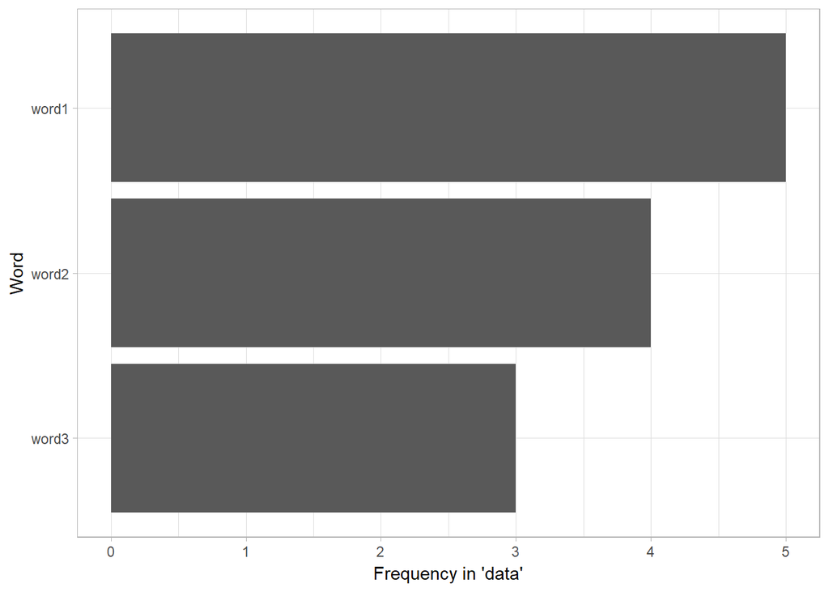

```r
ggplot (data = data_freq, aes(reorder(word, text_order), n)) +
  geom_bar (stat = "identity") +
  labs(x = "Word", y= "Frequency in 'data'") +
  coord_flip()+
  theme_light()
```

## Word Associations via n-grams

This time, instead of creating a tibble where each word is on a different row, we are going to create a tibble where each row is a sequential pair of words (bigrams). This creates repetition, in the first two rows of the new tibble `data_eng` there is an overlap, row1-column2’s ‘word1’ is the same as row2-column1’s ‘word1’ (this will become more clear in a realistic dataset)

```r
data_eng <- data_tb %>%
    unnest_tokens(bigram, text, token = "ngrams", n = 2)

data_eng
```

```
## # A tibble: 14 x 1
##         bigram
##          <chr>
##  1 word1 word1
##  2 word1 word2
##  3 word2 word1
##  4 word1 word2
##  5 word2 word3
##  6 word3 word1
##  7 word1 word2
##  8 word2 word3
##  9 word3 word4
## 10 word4 word1
## 11 word1 word2
## 12 word2 word3
## 13 word3 word4
## 14 word4 word5
```

We can count the bigrams in the same was as before

```r
bigramcount <- data_eng %>%
  count (bigram, sort = TRUE)
bigramcount
```

```
## # A tibble: 8 x 2
##        bigram     n
##         <chr> <int>
## 1 word1 word2     4
## 2 word2 word3     3
## 3 word3 word4     2
## 4 word1 word1     1
## 5 word2 word1     1
## 6 word3 word1     1
## 7 word4 word1     1
## 8 word4 word5     1
```

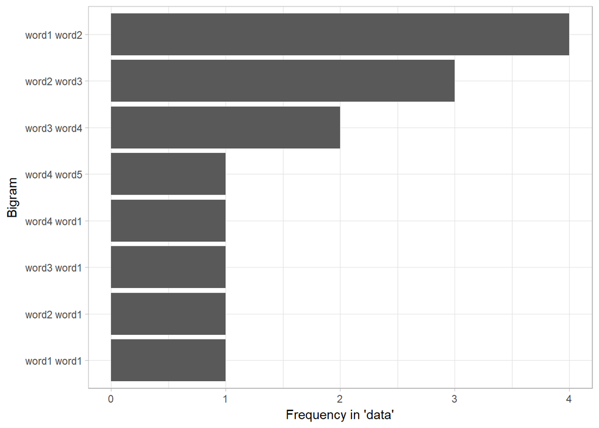

```r
ggplot (data = bigramcount, aes(x = (reorder(bigram,n)), y = n)) +
  geom_bar (stat = "identity") +
  labs(x = "Bigram", y= "Frequency in 'data'") +
  coord_flip()+
  theme_light()
```

# Exploring More Realistic Data

As with all analysis, text mining is only as good as the interpretation you put on it. Here, I see some considerable advantages of `tidytext` over the `tm` package, which only became clear to me after trying this out on a ‘proper’ dataset.

## Exploring it the tm Way

```r
dtm.example <- DocumentTermMatrix(example.c)
print ("Term Document Matrix")
```

```
## [1] "Term Document Matrix"
```

```r
head(as.matrix(TermDocumentMatrix(example.c)))
```

```
##           Docs
## Terms      1 2 3 4 5 6 7 8 9 10
##   about    1 0 0 0 0 0 1 0 0  0
##   feedback 1 1 1 0 2 0 0 0 0  0
##   monkeys  1 0 0 0 0 0 0 0 0  0
##   talk     1 0 0 0 0 0 0 0 0  0
##   animals  0 1 0 0 0 0 0 0 0  0
##   are      0 1 0 0 0 0 1 0 0  0
```

```r
print ("Three most frequent terms")
```

```
## [1] "Three most frequent terms"
```

```r
findFreqTerms(dtm.example, 3)
```

```
## [1] "feedback" "cats"     "dogs"
```

```r
print("Correlations with 'feedback'")
```

```
## [1] "Correlations with 'feedback'"
```

```r
findAssocs(dtm.example, "feedback", 0)
```

```
## $feedback
##     but    like    hate    love monkeys    talk animals    lots   there
##    0.75    0.37    0.37    0.37    0.25    0.25    0.25    0.25    0.25
##     who     too   about     are    cats    dogs
##    0.25    0.25    0.00    0.00    0.00    0.00
```

With this more realistic data we can see some of the problems with `findAssocs` - namely that “monkeys” has a moderate correlation with “feedback” (r = 0.25), despite only appearing once in the whole dataset, while “cats” has no correlation with “feedback” despite also appearing in one document with “feedback”.

The manual correlation for this can be seen here:

```r
as.matrix(DocumentTermMatrix(example.c))
```

```
##     Terms
## Docs about feedback monkeys talk animals are like lots there who too
##   1      1        1       1    1       0   0    0    0     0   0   0
##   2      0        1       0    0       1   1    1    1     1   1   0
##   3      0        1       0    0       0   0    1    0     0   0   1
##   4      0        0       0    0       0   0    0    0     0   0   0
##   5      0        2       0    0       0   0    0    0     0   0   0
##   6      0        0       0    0       0   0    0    0     0   0   0
##   7      1        0       0    0       0   1    0    0     0   0   0
##   8      0        0       0    0       0   0    0    0     0   0   0
##   9      0        0       0    0       0   0    0    0     0   0   0
##   10     0        0       0    0       0   0    0    0     0   0   0
##     Terms
## Docs animal biggest blue can now right the think whale but cats dogs hate
##   1       0       0    0   0   0     0   0     0     0   0    0    0    0
```

[output cut: 33 more lines]

```r
# Let's correlate 'feedback' with 'cats'
cor(c(1,1,1,0,2,0,0,0,0,0), c(0, 0,0,0,1,1,0,1,0,1))
```

```
## [1] 0
```

This is the big fundamental challenge of exploring text via corpora - **the ‘document’ is an observation.**

## Exploring it the tidytext way

Instead of using a corpus, we load the data in a tibble

```r
example_tb <- tibble(text = example)
example_tb_un <- example_tb %>%
  unnest_tokens(word, text)
```

Note that the `unnest` function has also converted all the text to lower case (this can be changed with the `to_lower = FALSE` argument, but I wouldn’t recommend that)

```r
head(example_tb)
```

```
## # A tibble: 6 x 1
##                                                            text
##                                                           <chr>
## 1                                   Monkeys talk about feedback
## 2                   There are lots of animals who like feedback
## 3                                           I like feedback too
## 4 The biggest animal I can think of right now is the blue whale
## 5                     Cats love feedback but dogs hate feedback
## 6     Cats hate assessment though even when dogs really love it
```

```r
head(example_tb_un)
```

```
## # A tibble: 6 x 1
##       word
##      <chr>
## 1  monkeys
## 2     talk
## 3    about
## 4 feedback
## 5    there
## 6      are
```

In this instance, the `example_tb_un` is putting all the words together - we will want to group these by respondent.

```r
example_tb <- add_column (example_tb, respondent = 1:10)
example_tb <- example_tb %>%
  mutate(respondent = str_c("A", str_pad(respondent, 3, "left", "0")))
example_tb_un <- example_tb %>%
  unnest_tokens(word, text)
example_tb_un$respondent <- as.factor(example_tb_un$respondent)

example_tb_un
```

```
## # A tibble: 68 x 2
##    respondent     word
##        <fctr>    <chr>
##  1       A001  monkeys
##  2       A001     talk
##  3       A001    about
##  4       A001 feedback
##  5       A002    there
##  6       A002      are
##  7       A002     lots
##  8       A002       of
##  9       A002  animals
## 10       A002      who
## # ... with 58 more rows
```

Now we can see what words belong (sequentially) to what comment.

### Stop Words

With a real example we want to take an intermediate step in the data and lose the stop words. This can also be done in the `tm` package, but as the `tm` package deals with corpora, we need a way of doing this in `tidytext`. The function `anti_join` will do this nicely, telling R not to join the words on the common English stop words list (e.g. the, a, it, etc.).

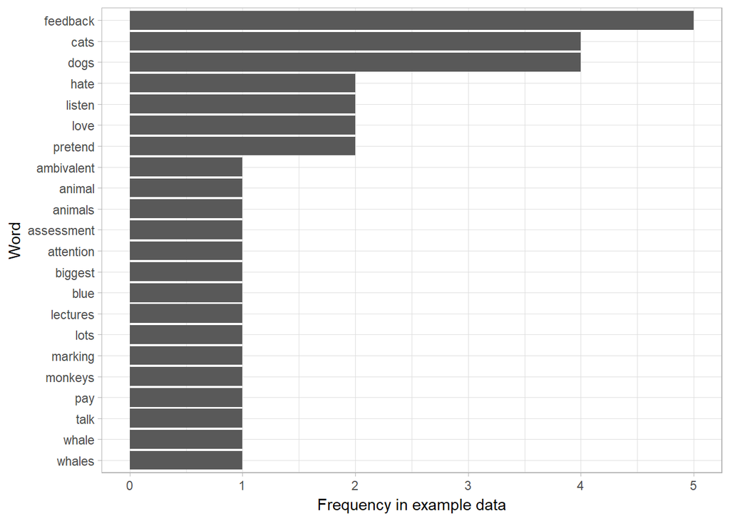

```r
example_freq <- example_tb_un %>%
  anti_join(stop_words) %>%
  count(word, sort = TRUE) %>%
  top_n (10) %>%
  mutate(text_order = nrow(.):1) %>%
  ggplot(aes(reorder(word, text_order), n)) +
  geom_bar (stat = "identity") +
  labs (x = "Word", y = "Frequency in example data") +
  coord_flip() +
  theme_light()
example_freq
```

Or we can also do this by respondent … (there would be data confidentiality issues doing this usually, but it’s a good way to demonstrate a grouping factor)

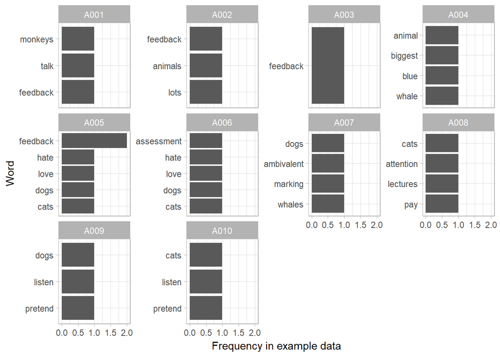

```r
example_tb_un %>%
  anti_join(stop_words) %>%
  group_by (respondent) %>%
  count(word, sort = TRUE) %>%
  top_n (10) %>%
  ungroup() %>%
  mutate(text_order = nrow(.):1) %>%
  ggplot(aes(reorder(word, text_order), n)) +
  geom_bar (stat = "identity") +
  labs (x = "Word", y = "Frequency in example data") +
  coord_flip() +
    facet_wrap(~ respondent, scales = "free_y") +
  theme_light()
```

### Lemmatisation

You’ll notice that in the above, ‘whale’ and ‘whales’ both exist as individual words, as do ‘animal’ and ‘animals’. We can use the `lemmatise_strings` function to deal with this. This is another package (`textstem`) but again, works nicely with `tidytext` as it doesn’t rely on corpora.

```r
example_tb_un$lemword <- lemmatize_strings(example_tb_un$word)
example_tb_un
```

```
## # A tibble: 68 x 3
##    respondent     word  lemword
##        <fctr>    <chr>    <chr>
##  1       A001  monkeys   monkey
##  2       A001     talk     talk
##  3       A001    about    about
##  4       A001 feedback feedback
##  5       A002    there    there
##  6       A002      are       be
##  7       A002     lots      lot
##  8       A002       of       of
##  9       A002  animals   animal
## 10       A002      who      who
## # ... with 58 more rows
```

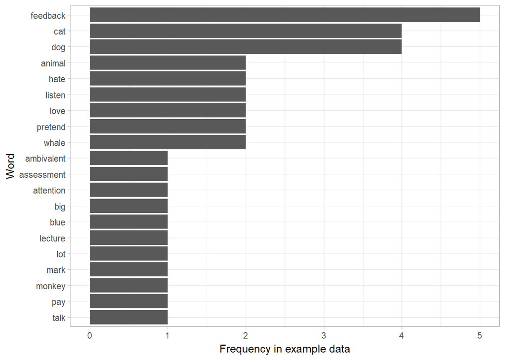

```r
all_freqs <- example_tb_un %>%
  anti_join(stop_words) %>%
  count(lemword, sort = TRUE) %>%
  top_n (10) %>%
  mutate(text_order = nrow(.):1) %>%
  ggplot(aes(reorder(lemword, text_order), n)) +
  geom_bar (stat = "identity") +
  labs (x = "Word", y = "Frequency in example data") +
  coord_flip() +
  theme_light()
all_freqs
```

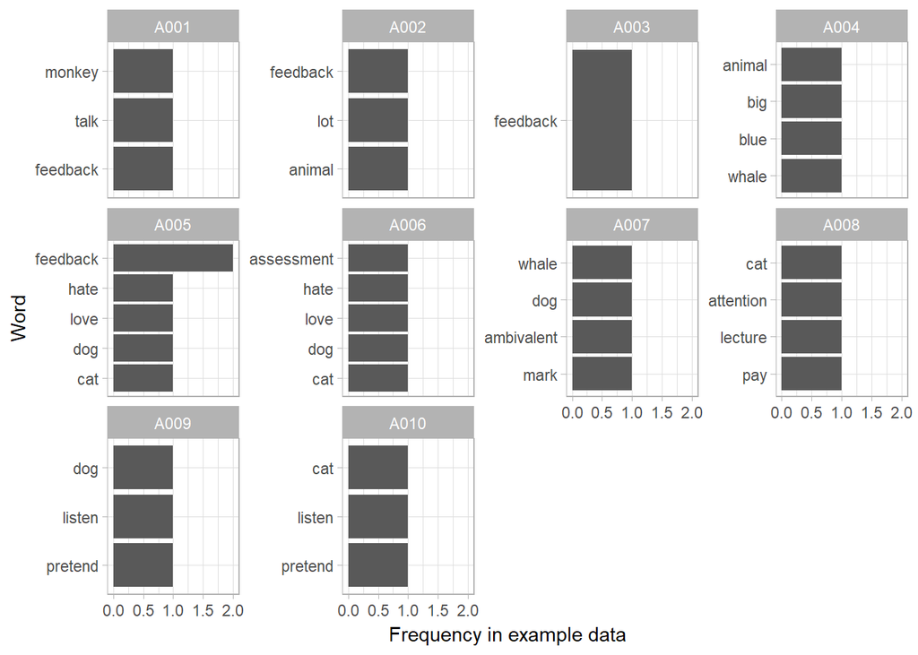

```r
freqs_by_respondent <- example_tb_un %>%
  anti_join(stop_words) %>%
  group_by (respondent) %>%
  count(lemword, sort = TRUE) %>%
  top_n (10) %>%
  ungroup() %>%
  mutate(text_order = nrow(.):1) %>%
  ggplot(aes(reorder(lemword, text_order), n)) +
  geom_bar (stat = "identity") +
  labs (x = "Word", y = "Frequency in example data") +
  coord_flip() +
    facet_wrap(~ respondent, scales = "free_y") +
  theme_light()
freqs_by_respondent
```

## n grams

Let’s look again at ngrams, this time with our more realistic dataset and what we know of stopwords.

```r
bigram_ex <- example_tb %>%
  unnest_tokens(bigram, text, token = "ngrams", n=2)
bigram_ex$respondent <- as.factor(bigram_ex$respondent)

bigram_ex
```

```
## # A tibble: 58 x 2
##    respondent         bigram
##        <fctr>          <chr>
##  1       A001   monkeys talk
##  2       A001     talk about
##  3       A001 about feedback
##  4       A002      there are
##  5       A002       are lots
##  6       A002        lots of
##  7       A002     of animals
##  8       A002    animals who
##  9       A002       who like
## 10       A002  like feedback
## # ... with 48 more rows
```

```r
#Most Common Bi-grams
bigram_ex %>%
  count (bigram, sort = TRUE)
```

```
## # A tibble: 56 x 2
##              bigram     n
##               <chr> <int>
##  1    like feedback     2
##  2        to listen     2
##  3   about feedback     1
##  4    about marking     1
##  5 ambivalent about     1
##  6         and dogs     1
##  7         animal i     1
##  8      animals who     1
##  9   are ambivalent     1
## 10         are lots     1
## # ... with 46 more rows
```

Now let’s filter out stop words, this is a little uglier than `tm`’s function, but better results.

```r
bigram_ex %>%
  separate (bigram, c("word1", "word2"), sep = " ") %>%
  filter (!word1 %in% stop_words$word,
          !word2 %in% stop_words$word) %>%
  count(word1, word2, sort = TRUE)
```

```
## # A tibble: 12 x 3
##      word1      word2     n
##      <chr>      <chr> <int>
##  1 biggest     animal     1
##  2    blue      whale     1
##  3    cats       hate     1
##  4    cats       love     1
##  5    cats        pay     1
##  6    cats    pretend     1
##  7    dogs       hate     1
##  8    dogs    pretend     1
##  9    hate assessment     1
## 10    hate   feedback     1
## 11    love   feedback     1
## 12 monkeys       talk     1
```

And of course we can lemmatise these words and visualise too . . .

```r
bigram_ex$lembigram <- lemmatize_strings(bigram_ex$bigram)


bigramfreq <- bigram_ex %>%
  separate (lembigram, c("word1", "word2"), sep = " ") %>%
  filter (!word1 %in% stop_words$word,
          !word2 %in% stop_words$word) %>%
  count(word1, word2, sort = TRUE) %>%
  unite("lembigram", c(word1,word2), sep = " ") %>%
  top_n (10)
bigramfreq
```

```
## # A tibble: 11 x 2
##          lembigram     n
##              <chr> <int>
##  1      blue whale     1
##  2        cat hate     1
##  3        cat love     1
##  4         cat pay     1
##  5     cat pretend     1
##  6        dog hate     1
##  7     dog pretend     1
##  8 hate assessment     1
##  9   hate feedback     1
## 10   love feedback     1
## 11     monkey talk     1
```

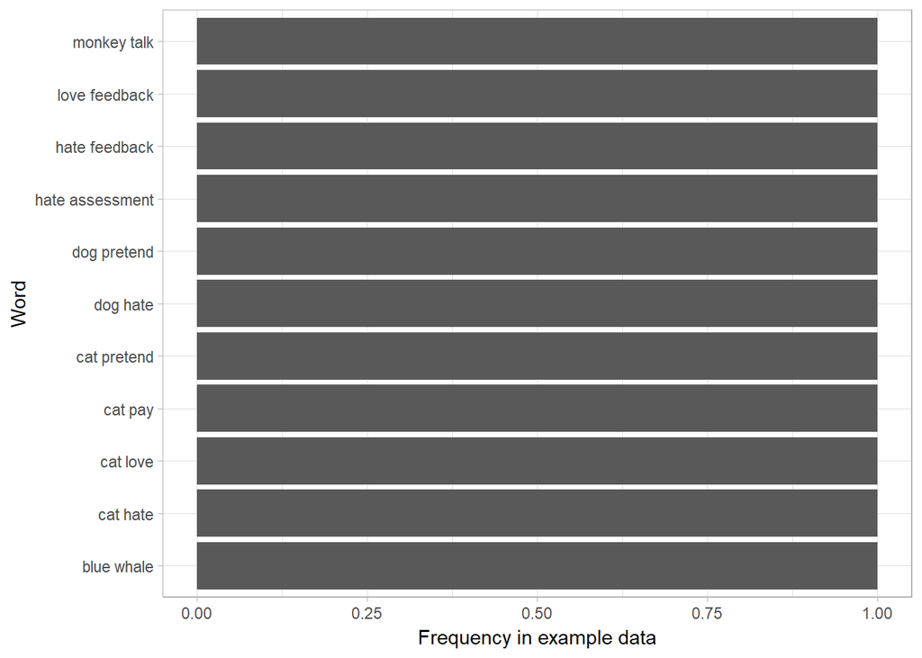

```r
ggplot(data = bigramfreq, aes(x = (reorder(lembigram, n)), y = n)) +
  geom_bar (stat = "identity") +
  labs (x = "Word", y = "Frequency in example data") +
  coord_flip() +
  theme_light()
```